# RNA-Seq Final Project

### **`TrimGalore`**

Found later in this report, after observing the first application of `FastQC` to the raw FastQ data files, highly repeated sequences were found. In order to both detect and remove these sequences from the raw input FastQ data, we can use the [`TrimGalore`](https://www.bioinformatics.babraham.ac.uk/projects/trim_galore/). Also written an maintained by the Bioinformatics Group at the [Babraham Institute](http://www.babraham.ac.uk/).

`TrimGalore` is a wrapper tool, providing the functionality of both `Cutadapt` and `FastQC` to provided adapter trimming and quality control to FastQ files. This report does not make use of the `FastQC` functionality of `TrimGalore` in order to seperate the QC and raw data files in an easier to understand way, calling `FastQC` directly with the required arguments.

**Key TrimGalore Commands**

```bash
$trim_galore $fastq_files \
--output_dir="${trim_galore_outdir}" \
--cores 14 --phred33 --gzip
```

### **`STAR`**

With over **16,787** citations on [Google Scholar](https://scholar.google.com/scholar?hl=en&as_sdt=0%2C33&q=+STAR%3A+ultrafast+universal+RNA-seq+aligner+&btnG=), `STAR` (Spliced Transcripts Alignment to a Reference) has proven to be a great tool for RNA-seq alignment.

It is best to first assemble a reference built upon your organism - gene model of interest with `STAR --runMode genomeGenerate`, followed by mapping your RNA-seq reads with `STAR --runMode alignReads`. Durning alignment, `STAR` takes as input single-end or pair-end fastq files, with the output file being in `SAM` (Spliced Alignment/Mapping) format. The `sam` file should then usually be converted into `BAM` (Binary Alignment/Mapping) file, a binary file of sam, for shortening computation time in further analyzing differential expression within RNA-seq data.

**Key STAR Commands**:

Earlier in this report, we have generated our `STAR` reference index with the following command:

```bash
STAR --runMode  genomeGenerate \
--runThreadN 16 \
--genomeDir human_genome_38_STAR_index \
--genomeFastaFiles human_genome_38/hg38.fa \
--sjdbGTFfile human_genome_38/gencode.v36.annotation.gtf.gz \
--sjdbOverhang 49
```

Given the raw or adapter-trimmed FastQ files, as well as the reference index we have generated in the previous command, we can align reads in the following way:

```bash
STAR --runMode  alignReads \
  --runThreadN 12 \
  --genomeDir  human_genome_38_STAR_index \
  --readFilesIn  $fastq_file \
  --readFilesCommand  zcat \
  --outSAMtype  BAM  SortedByCoordinate \
  --outFileNamePrefix $prefix  \
  --outSAMattributes All \
  --outReadsUnmapped="Fastx" \
  --outTmpKeep="None"
```

### **`featureCounts`**

`featureCounts` is an [“efficient general purpose program for assigning sequence reads to genomic features”](https://pubmed.ncbi.nlm.nih.gov/24227677/) and serves as a great [software program developed for counting reads to genomic features such as genes, exons, promoters and genomic bins](http://subread.sourceforge.net/)

**Key featureCounts Command**

```bash
featureCounts \
-a $annot_file \
-o $out_file \
-T 14 $bam_files
```

### **Data Processing Script**

In the script below, once all of the files are trimmed and saved, `FastQC` (paired with `multiqc` aggregation) is used to facilitate sequence quality control.

**Script for data processing:**

```bash
#!/bin/bash

data_storage_dir="/Genomic_Data_Storage/Alzheimers_Project"
trim_galore="/home/t730/TrimGalore/TrimGalore-0.6.6/trim_galore"

cell_type="myeloid"
fastq_files=$(ls "${data_storage_dir}/${cell_type}_fastq_files"/*.fastq.gz)

trim_galore_outdir="${data_storage_dir}/trimmed_${cell_type}_fastqs"
mkdir $trim_galore_outdir

fastqc_outdir="${data_storage_dir}/trimmed_${cell_type}_fastqc"
mkdir $fastqc_outdir

$trim_galore $fastq_files \
--output_dir="${trim_galore_outdir}" \
--cores 14 --phred33 --gzip

trimmed_files=$(ls $trim_galore_outdir/*.fq.gz)

fastqc $trimmed_files \
--outdir=$fastqc_outdir \
--threads=14 --noextract

cd $fastqc_outdir
multiqc .

for fastq_file in $trimmed_files; do
  base=$(basename $fastq_file)
  prefix=$(echo $fastq_file | egrep -o "SRR[0-9]+")
  prefix="trimmed_${cell_type}_alignments/${prefix}_trimmed."

  STAR --runMode  alignReads \
  --runThreadN 12 \
  --genomeDir  human_genome_38_STAR_index \
  --readFilesIn  $fastq_file \
  --readFilesCommand  zcat \
  --outSAMtype  BAM  SortedByCoordinate \
  --outFileNamePrefix $prefix  \
  --outSAMattributes All \
  --outReadsUnmapped="Fastx" \
  --outTmpKeep="None"

  samtools index ${prefix}.Aligned.sortedByCoord.out.bam
done

annot_file=${data_storage_dir}/human_genome_38/gencode.v36.annotation.gtf
out_dir=${data_storage_dir}/featureCounts
alignment_dir=${data_storage_dir}/trimmed_${cell_type}_alignments
out_file=${out_dir}/featCounts_genes.txt
bam_files=$(ls ${alignment_dir}/SRR???????_trimmed.Aligned.sortedByCoord.out.bam)

mkdir $out_dir

featureCounts \
-a $annot_file \
-o $out_file \
-T 14 $bam_files
```

[Trimmed MultiQC HTML Report](https://jakesauter.github.io/Next_Gen_Sequencing_Project/trimmed_myeloid_multiqc_report.html)

## **Quality Control**

### **`FastQC` Raw Data QC**

Signs of cyclic GC content for some runs are present in the dataset, however fastq tile coordinates **are not available** in the GEO dataset to allow for selective tile filtering ([Github issue showing why SRA may not store this information](https://github.com/ncbi/sra-tools/issues/130)). Particularly these issues were seen in three of the samples, with the effects occurring with varying degree. These samples were

- `SRR8440539` [FastQC Report](https://jakesauter.github.io/Next_Gen_Sequencing_Project/SRR8440539_fastqc.html)
- `SRR8440524` [FastQC Report](https://jakesauter.github.io/Next_Gen_Sequencing_Project/SRR8440524_fastqc.html)
- `SRR8440538` [FastQC Report](https://jakesauter.github.io/Next_Gen_Sequencing_Project/SRR8440538_fastqc.html)

An example of this failing behavior:

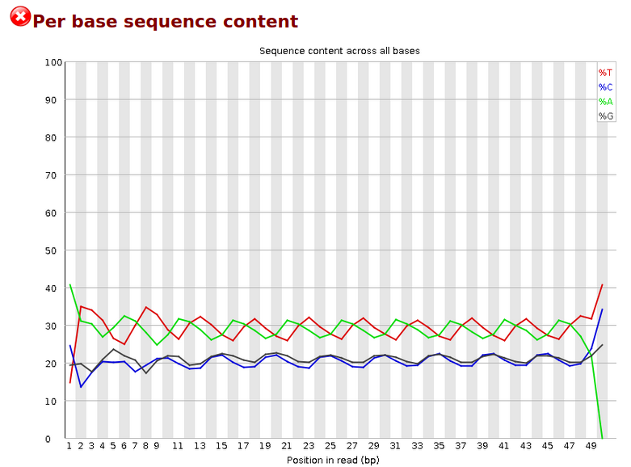

### **`STAR` Alignment QC**

In order to determine the percentage of reads mapped, we have used the `--outReadsUnmapped="Fastx"` parameter while running `STAR`, and now can compare the number of reads in our mapped files, versus the number of reads in our unmapped files. A `bash` function for performing this operation (`calculate_unampped_reads`) is applied to all of the `BAM` files generated in the `STAR` alignment phase of the report.

```bash
#!/bin/bash

data_storage_dir=/Genomic_Data_Storage/Alzheimers_Project

trim_fastq_dir=${data_storage_dir}/trimmed_myeloid_fastqs
trim_align_dir=${data_storage_dir}/trimmed_myeloid_alignments
bam_files=$(ls ${data_storage_dir}/trimmed_myeloid_alignments/*.bam)
parallel_tmp_dir=$(mktemp -d)

calculate_unampped_reads() {
  base=$(basename $1)
  prefix=$(echo $base | egrep -o "SRR[0-9]+")

  unammped_reads_file=${trim_align_dir}/${prefix}_trimmed.Unmapped.out.mate1
  total_reads_file=${trim_fastq_dir}/${prefix}_trimmed.fq.gz
  num_lines=$(cat $unammped_reads_file | wc -l)
  num_total_lines=$(zcat $total_reads_file | wc -l)
  perc_unmapped_reads=$(echo -e "(${num_lines}/${num_total_lines})*100" | bc -l | xargs printf %.2f)
  echo -e "Percentage of unmapped reads for ${prefix}: ${perc_unmapped_reads}%" > ${parallel_tmp_dir}/${prefix}.out
}

for bam_file in $bam_files; do
  calculate_unampped_reads $bam_file &
done

cat $parallel_tmp_dir/*.out
```

Results of executing this code can be found below.

```bash
Percentage of unmapped reads for SRR8440443: 5.90%
Percentage of unmapped reads for SRR8440447: 4.17%
Percentage of unmapped reads for SRR8440448: 4.04%
Percentage of unmapped reads for SRR8440449: 8.38%
Percentage of unmapped reads for SRR8440463: 33.79%
Percentage of unmapped reads for SRR8440477: 5.14%
Percentage of unmapped reads for SRR8440482: 6.54%
Percentage of unmapped reads for SRR8440484: 3.65%
Percentage of unmapped reads for SRR8440486: 8.13%
Percentage of unmapped reads for SRR8440488: 5.19%
Percentage of unmapped reads for SRR8440501: 6.98%
Percentage of unmapped reads for SRR8440511: 5.47%
Percentage of unmapped reads for SRR8440513: 6.79%
Percentage of unmapped reads for SRR8440514: 4.97%
Percentage of unmapped reads for SRR8440517: 5.76%
Percentage of unmapped reads for SRR8440518: 5.02%
Percentage of unmapped reads for SRR8440524: 11.28%
Percentage of unmapped reads for SRR8440525: 9.51%
Percentage of unmapped reads for SRR8440527: 7.05%
Percentage of unmapped reads for SRR8440529: 6.67%
Percentage of unmapped reads for SRR8440531: 10.64%
Percentage of unmapped reads for SRR8440536: 7.61%
Percentage of unmapped reads for SRR8440538: 7.43%
Percentage of unmapped reads for SRR8440539: 12.34%
Percentage of unmapped reads for SRR8440542: 8.16%
```

From the above output, we see that `SRR8440463` as an unusually high amount of unmapped reads compared to all other samples in the study. When cross-referenceing our previously generated `MultiQC` report from earlier, we can see that the GC content of this sample appears to be off compared to all other samples as well, possibly indicating contamination or other library quality issues.

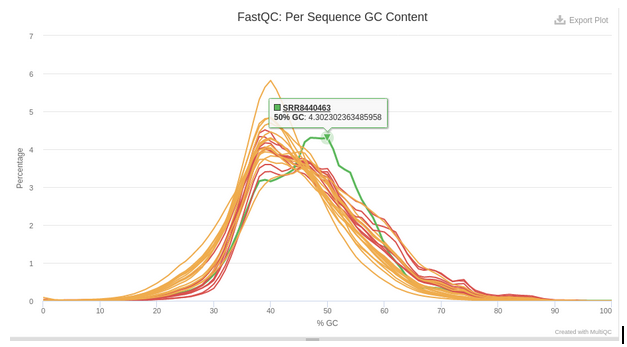

**Problematic cyclic GC samples from before**: `SRR8440524`, `SRR8440538`, and `SRR8440539` **NOT** `SRR8440463` that we see with GC-rich contamination above.

**FastQC Reports**:

- SRR8440524_fastqc.html
- SRR8440538_fastqc.html
- SRR8440539_fastqc.html
- SRR8440463_fastqc.html

We will keep these QC issues in mind moving forward, and remove the samples before analysis in `R`.

## **Data Analysis**

### **`DESeq2` Analysis of `featureCounts` Results**

Below we will use the `DESeq2` R package to make a `DESeqDataSet` from our resultant files from running featureCounts. At this step, I have chosen to remove our **4** samples with QC issues after preliminary analysis, as well as another **4** samples for having an undefined value (`NA`) for the **sex** attribute, a possible confounder analyzed in this report.

**Required Libraries**:

```r
library(tidyr)        # pivot_longer
library(knitr)        # Rmarkdown chunk options and kable
library(dplyr)        # filter, summarise
library(DESeq2)       # EDS and DE
library(ggplot2)      # Plotting
library(stringr)      # String searching and extraction
library(magrittr)     # Piping
library(patchwork)    # Image layout
library(plyranges)    # gtf file manipulation
library(rtracklayer)  # gtf file manipulation
```

**Importing `featureCounts` Data into `DESeq2`**

```r
read_counts <- read.table(
  '../featCounts/featCounts_genes.txt',
  header = TRUE, stringsAsFactors = FALSE)

orig_names <- colnames(read_counts)
colnames(read_counts) <- gsub(".*(SRR[0-9]+).*", "\\1", orig_names)
row.names(read_counts) <- make.names(read_counts$Geneid)
read_counts <- read_counts[,-c(1:6)]
read_counts <- as.matrix(read_counts)
```

**Filtering failed QC Samples**

```r
keep_samples <-
  colnames(read_counts) %in%
  c('SRR8440524', 'SRR8440463',
    'SRR8440538', 'SRR8440539',
    "SRR8440484", "SRR8440488",
    "SRR8440447", "SRR8440517"
    ) %>%
  not()

read_counts <-
  read_counts[ , keep_samples]

read_counts %>%
  .[1:4, 1:5] %>%
  kable()
```

|  | SRR8440443 | SRR8440448 | SRR8440449 | SRR8440477 | SRR8440482 |
| --- | --- | --- | --- | --- | --- |
| ENSG00000223972.5 | 0 | 0 | 0 | 0 | 0 |
| ENSG00000227232.5 | 0 | 1 | 0 | 0 | 0 |
| ENSG00000278267.1 | 0 | 0 | 0 | 0 | 0 |
| ENSG00000243485.5 | 0 | 0 | 0 | 0 | 0 |

**Converting gene count Ensembl IDs to cannoncical gene names using gene-data from gtf files**

**NOTE** : Some gencode ids map to the same gene symbol

**TODO**: Peform parallel analysis for long-non-coding RNAs or incoroporate into this analysis?

```r
genes_df <-
  read_gff("../gtf/gencode.v36.annotation.gtf.gz",
           genome_info="hg38") %>%
  select(gene_id, gene_type, gene_name) %>%
  as.data.frame()


gene_info_df <-
  data.frame(gencode_id = rownames(read_counts)) %>%
  left_join(., genes_df,
            by = c('gencode_id' = 'gene_id')) %>%
  select(gencode_id, gene_name, gene_type) %>%
  filter(#not(gene_type %in% c('lncRNA', 'Mt_rRNA', 'Mt_tRNA')),
         # TODO: going to move forward with only protein coding genes
         #      genes for now as long-non-coding RNAs and MT-rna
         #      seem to really be messing up my sizefactor normalization
         gene_type == 'protein_coding',
         !str_detect(gene_name, '^MT-')) %>%
  distinct()

read_counts <-
  read_counts[gene_info_df$gencode_id, ]
```

**Filtering mitochondrial reads**

Now that we have our raw read counts, lets gather information about our samples to supply to the `colData` parameter of `DESeqDataSetFromMatrix`.

```r
accession_table <-
  read.table('../accession_tables/Sra_run_table.txt',
             header = TRUE, sep = ',', stringsAsFactors = FALSE) %>%
  as.data.frame() %>%
  filter(Cell_type == 'myeloid',
         !is.na(sex)) %>%
  select(Run, Diagnosis, sex,
                expired_age, APOE, pmi,
                Cell_type) %>%
  arrange(Diagnosis, sex)

accession_table %>%
  kable()
```

| Run | Diagnosis | sex | expired_age | APOE | pmi | Cell_type |
| --- | --- | --- | --- | --- | --- | --- |
| SRR8440448 | AD | female | 84 | 3/4 | 3.00 | myeloid |
| SRR8440514 | AD | female | 78 | 3/4 | 2.16 | myeloid |
| SRR8440538 | AD | female | 84 | 3/3 | 1.83 | myeloid |
| SRR8440477 | AD | male | 88 | 3/4 | 3.00 | myeloid |
| SRR8440501 | AD | male | 79 | 3/3 | 2.00 | myeloid |
| SRR8440486 | AD | male | 75 | 3/3 | 3.00 | myeloid |
| SRR8440542 | AD | male | 70 | 3/4 | 2.33 | myeloid |
| SRR8440463 | AD | male | 72 | 4/4 | 4.16 | myeloid |
| SRR8440511 | Control | female | 59 | 3/3 | 3.15 | myeloid |
| SRR8440518 | Control | female | 88 | 3/3 | 3.00 | myeloid |
| SRR8440443 | Control | female | >90 | 3/3 | 2.50 | myeloid |
| SRR8440529 | Control | female | 83 | 3/3 | 3.25 | myeloid |
| SRR8440527 | Control | male | 79 | 3/3 | 3.00 | myeloid |
| SRR8440449 | Control | male | 74 | 2/3 | 3.25 | myeloid |
| SRR8440482 | Control | male | >90 | 2/3 | 1.50 | myeloid |
| SRR8440513 | Control | male | >90 | 3/3 | 1.50 | myeloid |
| SRR8440524 | Control | male | 86 | 3/3 | 4.75 | myeloid |
| SRR8440525 | Control | male | 86 | 3/3 | 3.00 | myeloid |
| SRR8440531 | Control | male | 38 | 3/3 | 3.00 | myeloid |
| SRR8440536 | Control | male | 61 | 3/3 | 2.33 | myeloid |
| SRR8440539 | Control | male | >90 | 3/3 | 3.00 | myeloid |

From this accession table, we can map our accession ids to any clinical variable we like, such as `Diagnosis`, which is our main experimental group condition in this analysis. `Diagnosis` in our case tells us whether or not the diseased patient showed signs of Alzheimer’s disease or not (control).

```r
conditions <-
  colnames(read_counts) %>%
  lapply(function(run_name)
      accession_table[accession_table['Run'] == run_name, ]) %>%
  bind_rows()


sample_info <-
  DataFrame(conditions,
            row.names = conditions$Run)


DESeq.ds <-
  DESeqDataSetFromMatrix(
    countData = as.matrix(read_counts),
    colData = sample_info,
    rowData = gene_info_df,
    design = ~ sex + Diagnosis)

DESeq.ds %>%
  colData() %>%
  head() %>%
  kable()
```

|  | Run | Diagnosis | sex | expired_age | APOE | pmi | Cell_type |
| --- | --- | --- | --- | --- | --- | --- | --- |
| SRR8440443 | SRR8440443 | Control | female | >90 | 3/3 | 2.50 | myeloid |
| SRR8440448 | SRR8440448 | AD | female | 84 | 3/4 | 3.00 | myeloid |
| SRR8440449 | SRR8440449 | Control | male | 74 | 2/3 | 3.25 | myeloid |
| SRR8440477 | SRR8440477 | AD | male | 88 | 3/4 | 3.00 | myeloid |
| SRR8440482 | SRR8440482 | Control | male | >90 | 2/3 | 1.50 | myeloid |
| SRR8440486 | SRR8440486 | AD | male | 75 | 3/3 | 3.00 | myeloid |

```r
DESeq.ds %>%
  counts() %>%
  head() %>%
  .[,1:5] %>%
  kable()
```

|  | SRR8440443 | SRR8440448 | SRR8440449 | SRR8440477 | SRR8440482 |
| --- | --- | --- | --- | --- | --- |
| ENSG00000186092.6 | 0 | 0 | 0 | 0 | 0 |
| ENSG00000284733.1 | 0 | 0 | 0 | 0 | 0 |
| ENSG00000284662.1 | 0 | 0 | 0 | 0 | 0 |
| ENSG00000187634.12 | 0 | 1 | 0 | 1 | 9 |
| ENSG00000188976.11 | 123 | 256 | 128 | 134 | 138 |
| ENSG00000187961.14 | 65 | 48 | 6 | 29 | 56 |

**Read Mapping Quality Assessment**

**Number of reads sequenced per sample**

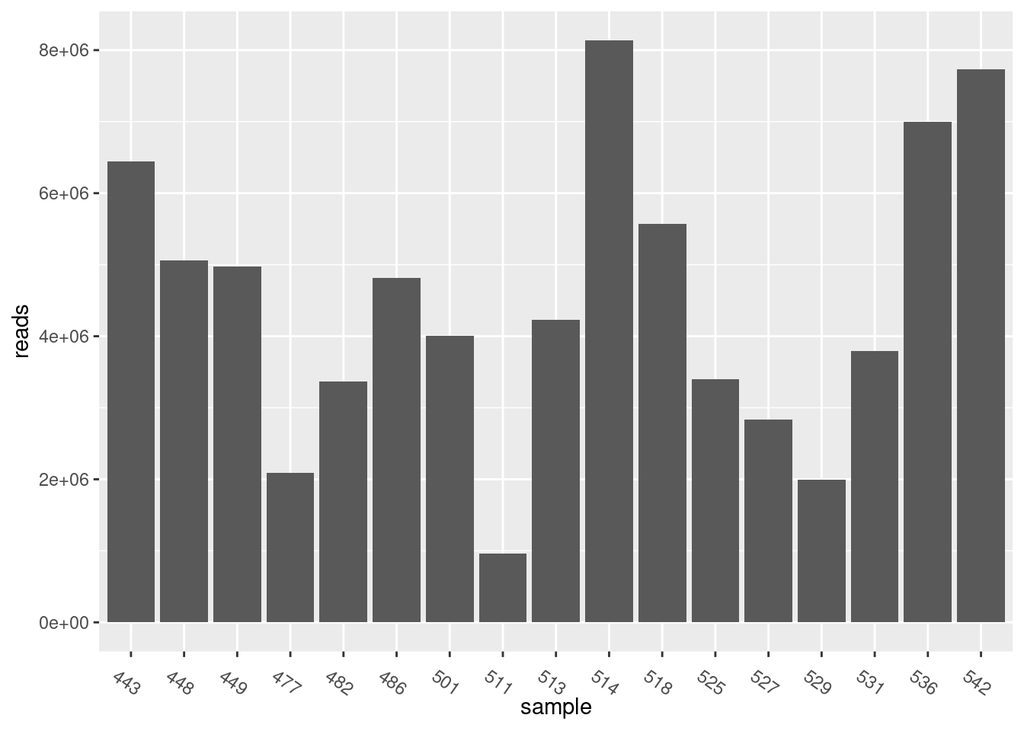

```r
colSums(counts(DESeq.ds)) %>%
  data.frame(sample = str_extract(names(.), '[0-9]{3}$'), reads = .) %>%
  ggplot() +
  geom_col(aes(x = sample, y = reads)) +
  theme(axis.text.x = element_text(angle=-35))
```

Moving forward, we will filter our `DESeqDataSet` as to only include genes that have a read mapped for at least one sample.

```r
n_previous_genes <- nrow(DESeq.ds)
keep_genes <- rowSums(counts(DESeq.ds)) > 0
DESeq.ds <- DESeq.ds[keep_genes, ]

cat(n_previous_genes - nrow(DESeq.ds), 'genes removed due to no non-zero counts found')
```

```
981 genes removed due to no non-zero counts found
```

**Normalizing read counts for Sequencing Depth**

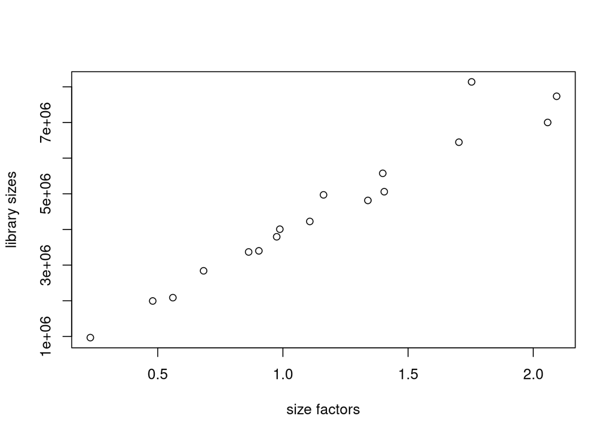

```r
DESeq.ds <- estimateSizeFactors(DESeq.ds)

plot(sizeFactors(DESeq.ds), colSums(counts(DESeq.ds)),
     ylab = 'library sizes', xlab = 'size factors')
```

From the plot above, we can see that our key necessary assumption that *size factors should be around 1 and scale with number of reads per sample** is met. However, this was not originally the case before some data filtering.

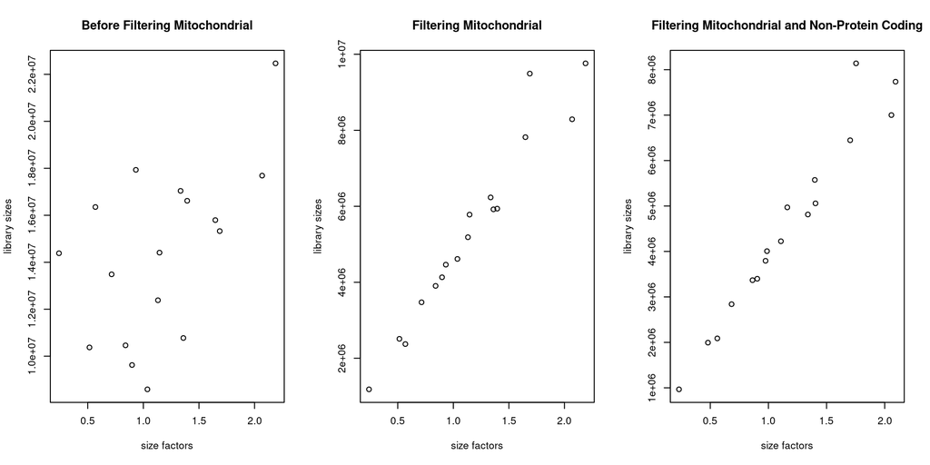

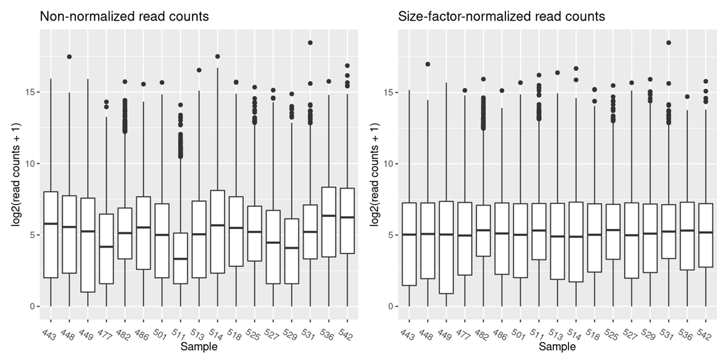

```r
p1 <-
  DESeq.ds %>%
  counts() %>%
  {. + 1} %>%
  log2() %>%
  as.data.frame() %>%
  pivot_longer(cols = everything()) %>%
  mutate(name = str_extract(name, '[0-9]{3}$')) %>%
  ggplot() +
    geom_boxplot(aes(x = name, y = value)) +
    ggtitle("Non-normalized read counts") +
    xlab('Sample') + ylab("log2(read counts + 1)") +
    theme(axis.text.x = element_text(angle = -30))


p2 <-
  DESeq.ds %>%
  counts(normalize= TRUE) %>%
  {. + 1} %>%
  log2() %>%
  as.data.frame() %>%
  pivot_longer(cols = everything()) %>%
  mutate(name = str_extract(name, '[0-9]{3}$')) %>%
  ggplot() +
    geom_boxplot(aes(x = name, y = value)) +
    ggtitle("Size-factor-normalized read counts") +
    xlab('Sample') + ylab("log2(read counts + 1)") +
    theme(axis.text.x = element_text(angle = -30))

p1 + p2
```

Again, this section has influenced the filtering I have applied

**No Gene Filtering Applied**

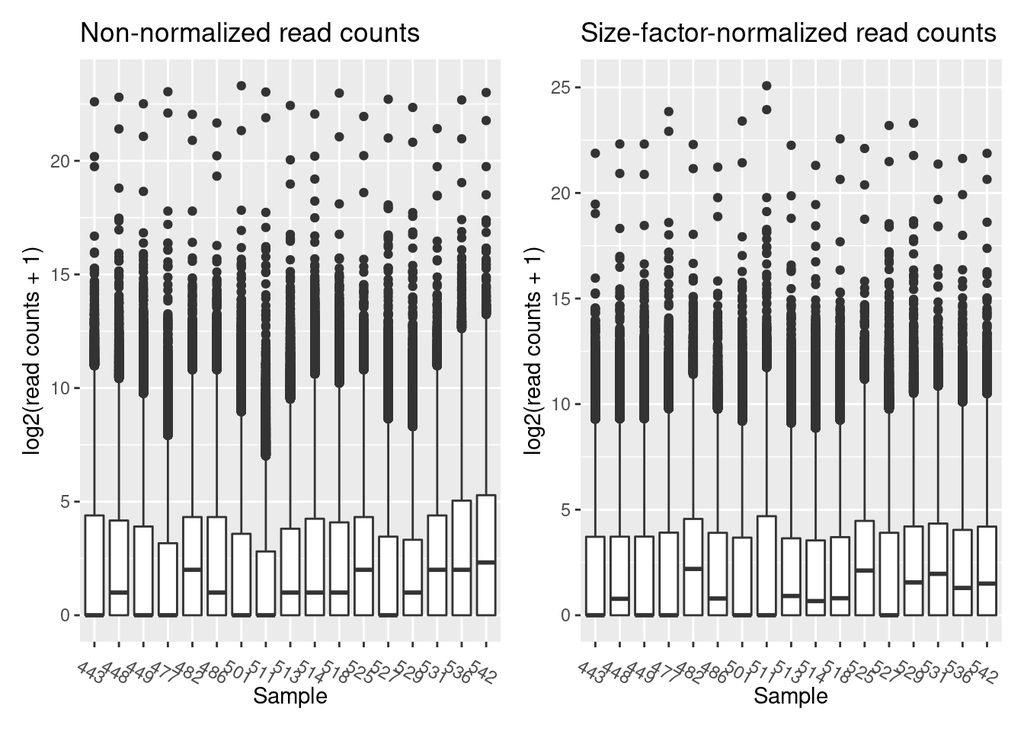

**Mitchondrial Gene Filtering Applied**

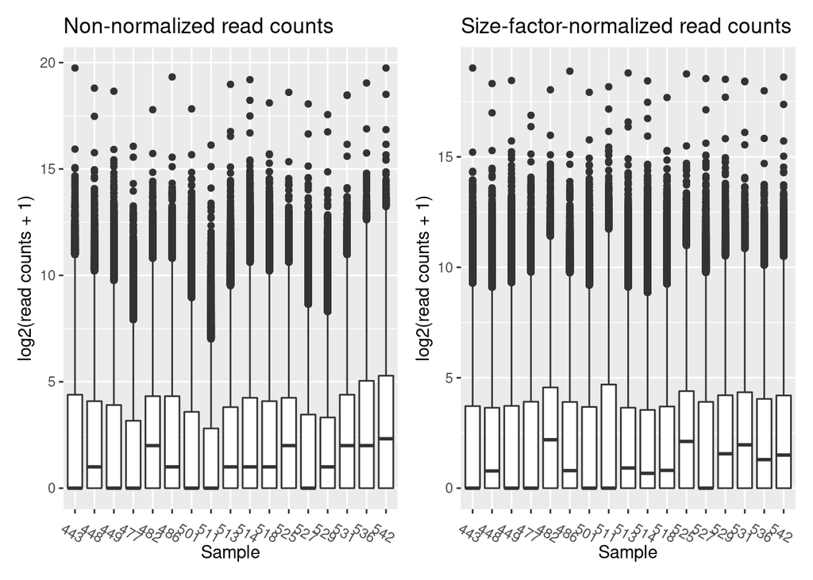

**Mitchondrial and Non Protein-Coding Filtering Applied**

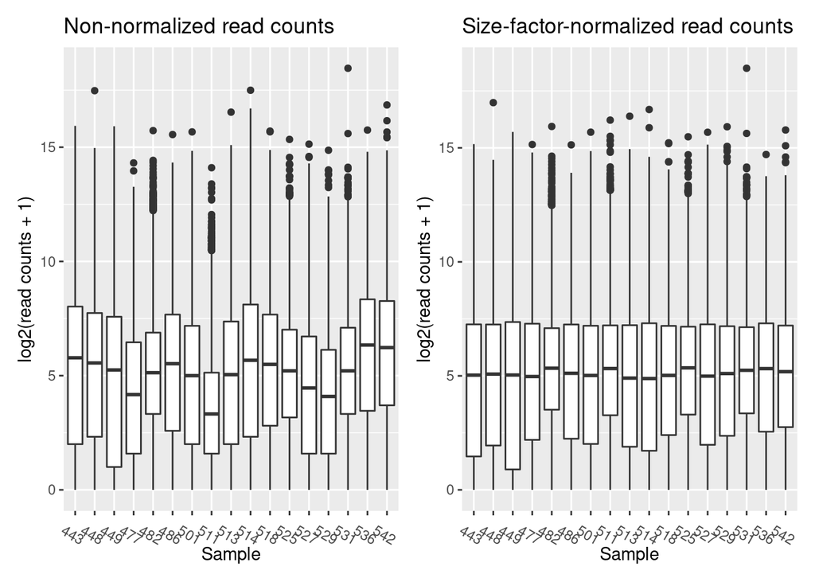

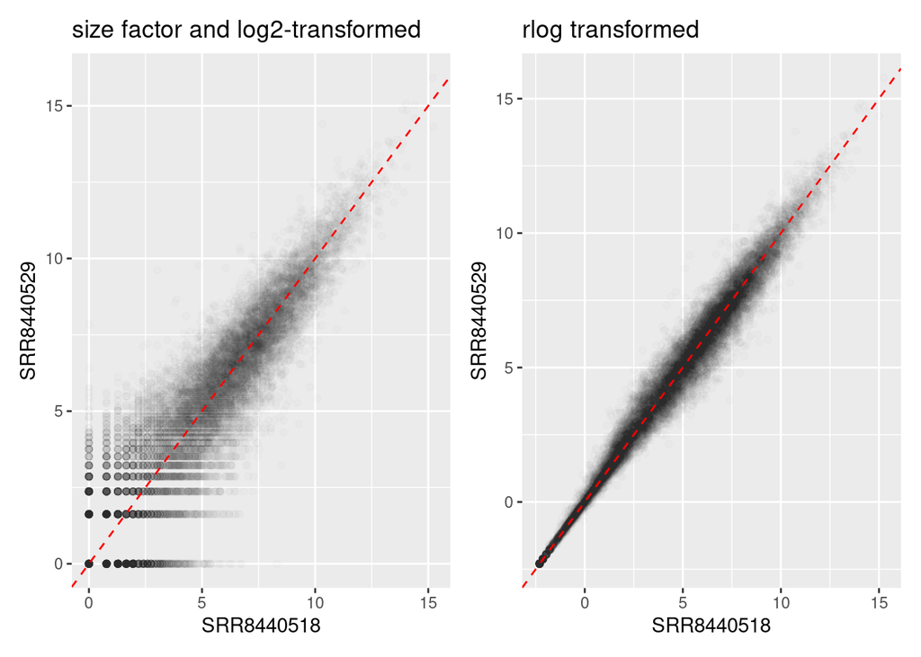

```r
DESeq.rlog <- rlog(DESeq.ds, blind = TRUE)

log.norm.counts <-
  DESeq.ds %>%
  counts(normalized=TRUE) %>%
  {.+1} %>%
  log2()


p1 <-
  data.frame('SRR8440518' = log.norm.counts[,'SRR8440518'],
           'SRR8440529' = log.norm.counts[,'SRR8440529']) %>%
  ggplot() +
  geom_point(aes(x = SRR8440518, y = SRR8440529),
             alpha = 0.01) +
  geom_abline(slope = 1, intercept = 0,
              lty = 2, col = 'red') +
  ggtitle("size factor and log2-transformed") +
  xlab('SRR8440518') + ylab('SRR8440529')

## the rlog-transformed counts are stored in the accessor "assay"
p2 <-
  data.frame('SRR8440518' = assay(DESeq.rlog)[,'SRR8440518'],
           'SRR8440529' = assay(DESeq.rlog)[,'SRR8440529']) %>%
  ggplot() +
  geom_point(aes(x = SRR8440518, y = SRR8440529),
             alpha = 0.01) +
  geom_abline(slope = 1, intercept = 0,
              lty = 2, col = 'red') +
  ggtitle("rlog transformed") +
  xlab('SRR8440518') + ylab('SRR8440529')


p1 + p2
```

**Mean vs Stdev before and after `rlog`**

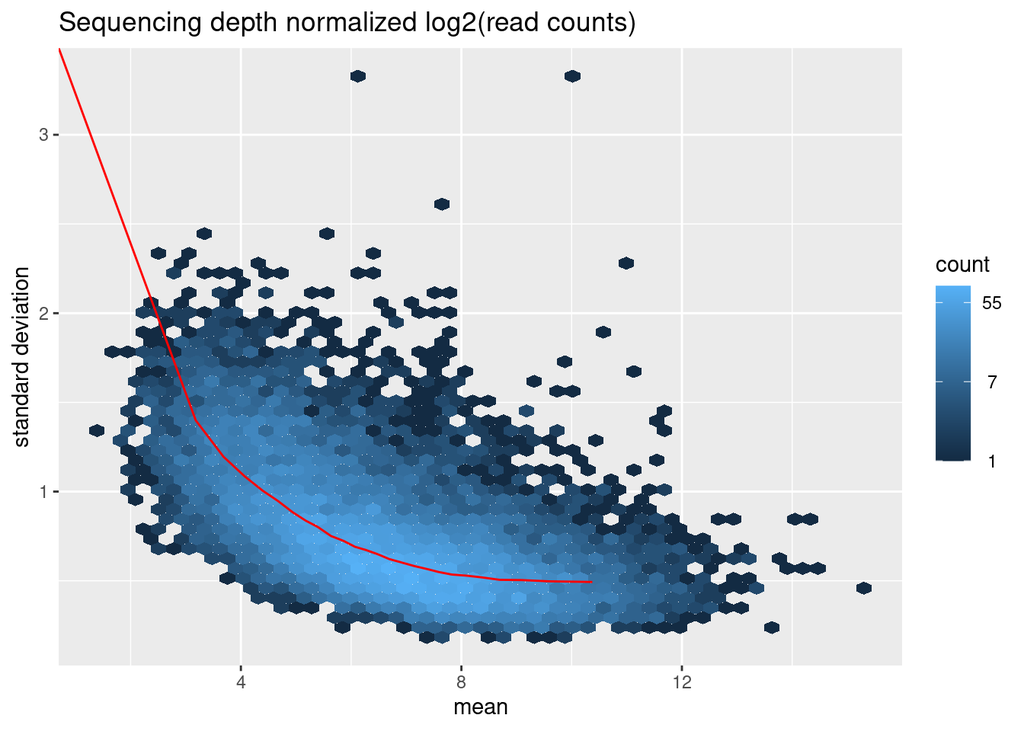

```r
par(mfrow = c(1, 2))

log.norm.counts <-
  DESeq.ds %>%
  counts(normalized=TRUE) %>%
  log2()

par(mfrow=c(1,1))

msd_plot <-
  vsn::meanSdPlot(log.norm.counts,
                  ranks=FALSE,
                  plot=FALSE)
msd_plot$gg +
  ggtitle("Sequencing depth normalized log2(read counts)") +
  ylab("standard deviation")
```

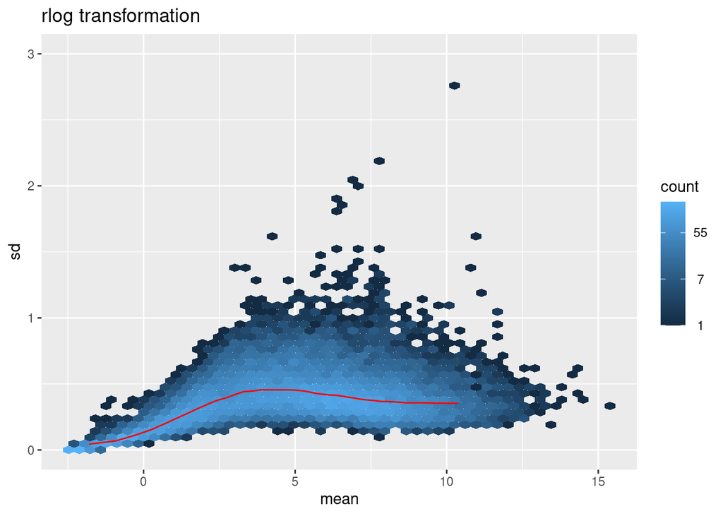

```r
rlog.norm.counts <-
  DESeq.rlog %>%
  assay()

msd_plot <-
  vsn::meanSdPlot(rlog.norm.counts,
                  ranks=FALSE,
                  plot = FALSE)

msd_plot$gg +
  ggtitle("rlog transformation") +
  coord_cartesian(ylim = c(0,3))
```